# Untitled

Ubaidillah Al Hakim

2023-10-16

# Tugas Pemodelan dan Diagnostik Model Arima

## Persiapan bahan untuk analisis

### Library

```r
library(rio)
library(tseries)
library(MASS)
library(TSA)
library(lmtest)
library(forecast)
```

### Input Data

```r
data <- import("https://raw.githubusercontent.com/Lagh23/MPDW/main/Praktikum%201/test.csv")
data
```

```
##     numb  Close
## 1      1  47.21
## 2      2  47.51
## 3      3  46.57
## 4      4  48.13
## 5      5  44.63
## 6      6  45.12
## 7      7  44.00
## 8      8  42.46
## 9      9  38.96
## 10    10  39.79
## 11    11  36.85
## 12    12  41.86
## 13    13  41.12
## 14    14  43.08
```

[output cut: 95 more lines]

### Partisi Data

```r
data.ts <- ts(data$Close)
data_train <- ts(data$Close[1:70])
data_test <- ts(data$Close[71:109])
data_train
```

```
## Time Series:
## Start = 1
## End = 70
## Frequency = 1
##  [1]  47.21  47.51  46.57  48.13  44.63  45.12  44.00  42.46  38.96  39.79
## [11]  36.85  41.86  41.12  43.08  44.53  46.39  47.51  46.70  51.39  53.01
## [21]  56.47  59.44  57.88  57.97  61.40  62.76  64.93  67.03  69.98  68.88
## [31]  73.22  73.03  73.78  74.83  72.31  70.12  68.78  70.58  73.14  77.78
## [41]  79.54  79.83  88.02  84.65  93.94  83.16  83.72  86.95  87.32  89.79
## [51]  94.85  92.96  97.19 104.85 100.91 104.20 104.92 111.85 118.59 116.41
## [61] 108.04  95.19  98.96 101.54 103.99 107.98 109.01 113.45 117.00 110.88
```

```r
data_test
```

```
## Time Series:
## Start = 1
## End = 39
## Frequency = 1
##  [1] 114.56 105.31 110.53 123.10 132.21 128.24 123.78 120.75 123.49 126.18
## [11] 117.91 120.26 109.05 107.38 107.59 105.25 104.68 102.87 101.19  95.76
## [21]  99.35  88.51  87.85  87.93  89.69  83.03  79.32  81.19  81.56  84.77
## [31]  77.56  81.29  83.30  84.86  82.48  80.99  84.93  74.65  81.85
```

## Eksplorasi Data

### Visualisasi data

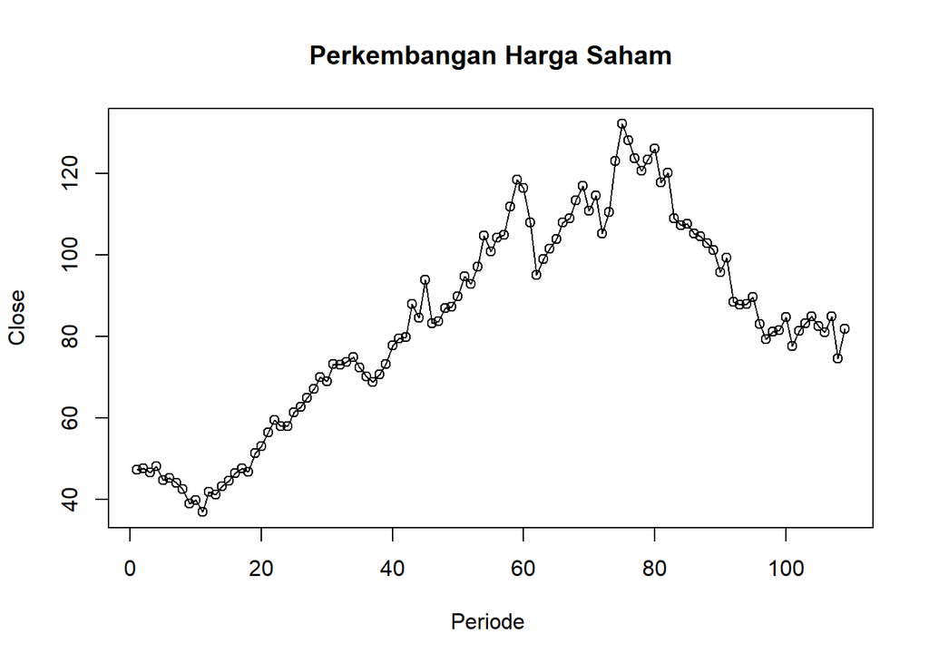

```r
## Plot Data Keseluruhan
ts.plot(data.ts, xlab="Periode ", ylab="Close",
        main = "Perkembangan Harga Saham")
points(data.ts)
```

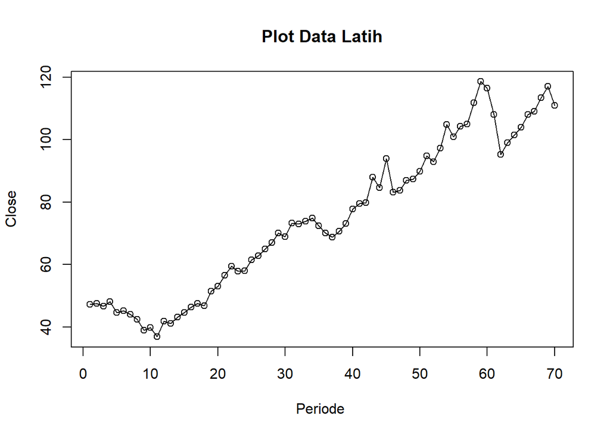

```r
## plot data latih
ts.plot(data_train, xlab="Periode ", ylab="Close",
        main = "Plot Data Latih")
points(data_train)
```

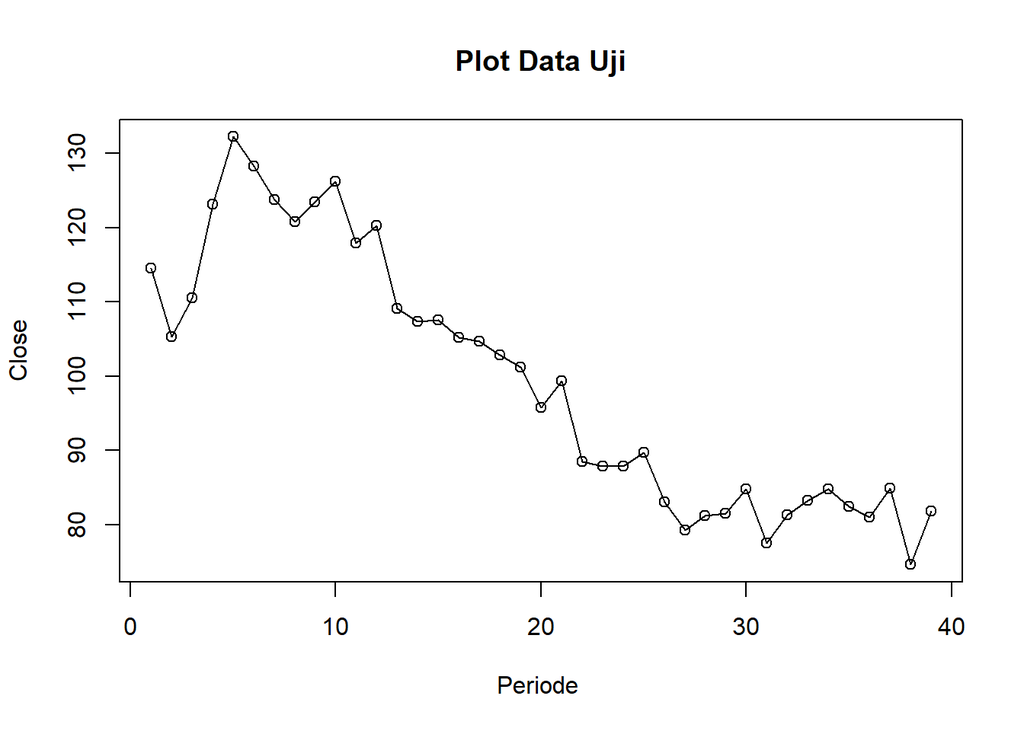

```r
## Plot data Uji
ts.plot(data_test, xlab="Periode ", ylab="Close",
        main = "Plot Data Uji")
points(data_test)
```

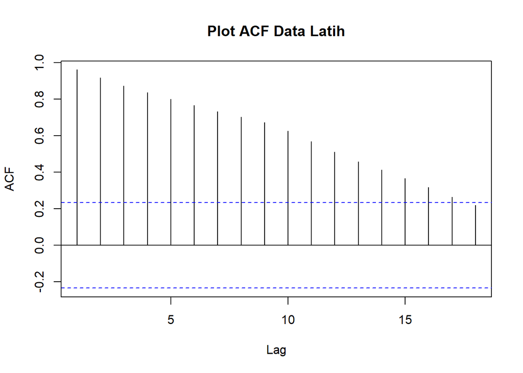

```r
## plot ACF data latih
acf(data_train, main = "Plot ACF Data Latih")
```

Berdasarkan plot ACF, terlihat bahwa plot ACF pada data tersebut menurun secara perlahan (*tails off slowly*) yang menandakan data tidak stasioner dalam rataan

### Uji ADF Data Latih

```r
adf.test(data_train)
```

```
##
##  Augmented Dickey-Fuller Test
##
## data:  data_train
## Dickey-Fuller = -3.2525, Lag order = 4, p-value = 0.08657
## alternative hypothesis: stationary
```

H_0 : Data tidak stasioner dalam rataan H_1 : Data stasioner dalam rataan

P val sebesar **0.08657** lebih besar dari taraf 5%, sehingga tak tolak H0, cukup bukti untuk mengatakan data tidak stasioner dalam rataan

### Boxcox Data Latih

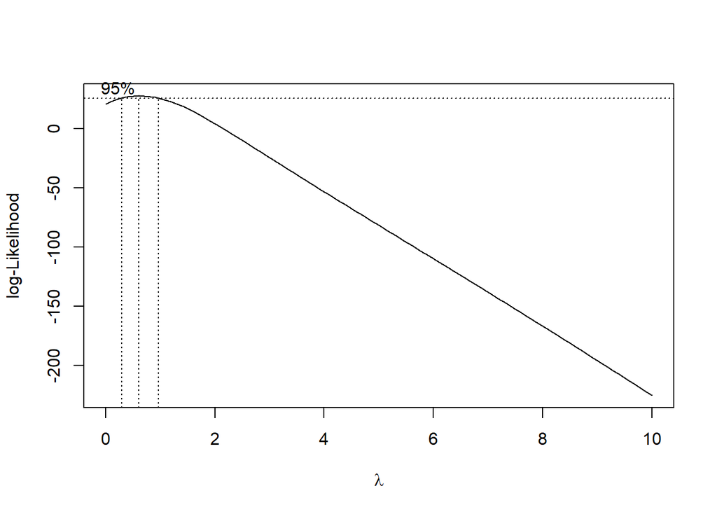

```r
#Plot Boxcox
index <- seq(1:length(data_train))
bc = boxcox(data_train~index, lambda = seq(0,10,by=1))
```

```r
#Nilai Lambda
lambda <- bc$x[which.max(bc$y)]
lambda
```

```
## [1] 0.6060606
```

```r
#SK
bc$x[bc$y > max(bc$y) - 1/2 * qchisq(.95,1)]
```

```
## [1] 0.3030303 0.4040404 0.5050505 0.6060606 0.7070707 0.8080808 0.9090909
```

Selang tersebut tidak memuat nilai satu sehingga dapat dikatakan bahwa data bangkitan tidak stasioner dalam ragam.

## Penanganan Tidak Stasioner

### Eksplorasi

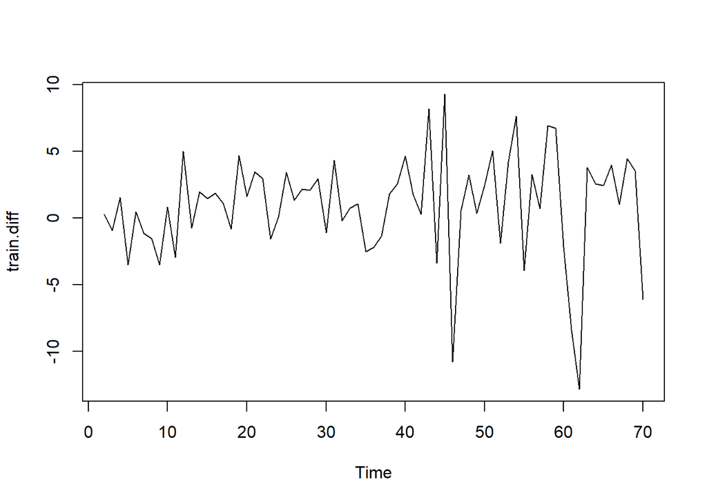

```r
train.diff<-diff(data_train,differences = 1)
plot.ts(train.diff)
```

### ACF dan Uji ADF

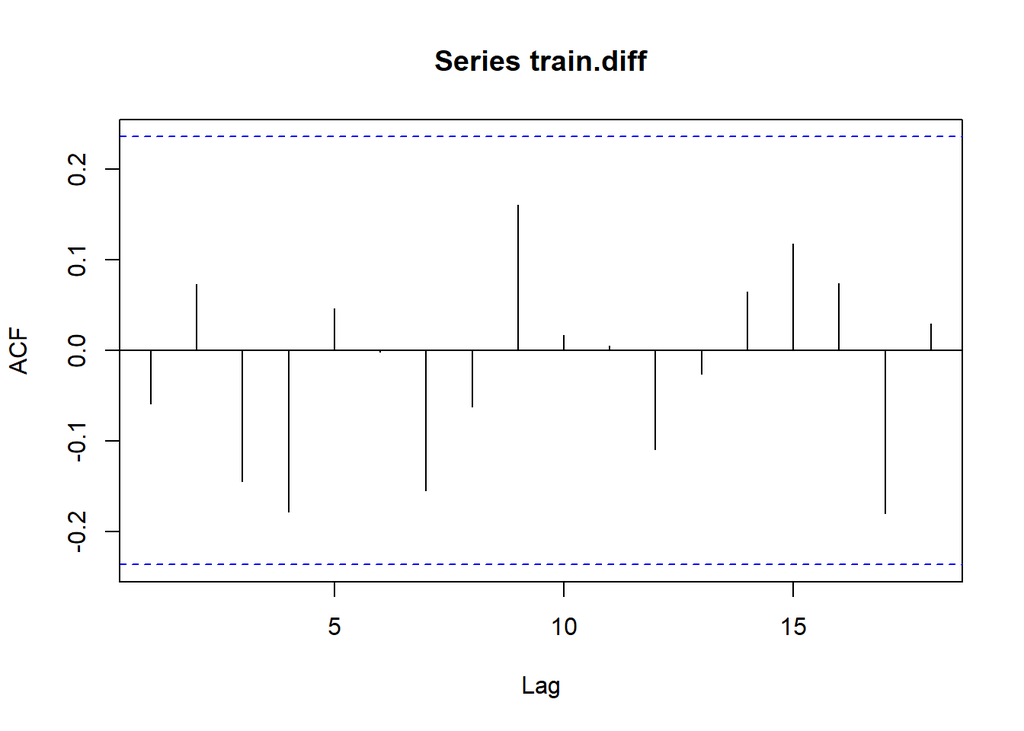

```r
acf(train.diff)
```

```r
adf.test(train.diff)
```

```
##
##  Augmented Dickey-Fuller Test
##
## data:  train.diff
## Dickey-Fuller = -4.0407, Lag order = 4, p-value = 0.01312
## alternative hypothesis: stationary
```

Hasil ADF : H_0 : Data tidak stasioner dalam rataan H_1 : Data stasioner dalam rataan P val sebesar **0.01312** lebih kecil dari taraf 5%, sehingga tolak H0, sehingga bisa dikatakan data cenderung stasioner dalam rataan.

### PACF

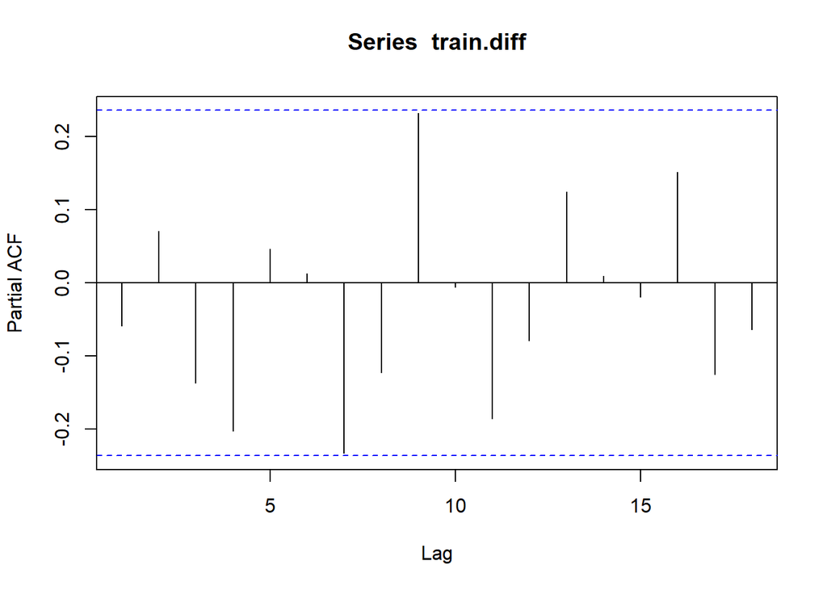

```r
pacf(train.diff)
```

### EACF

```r
eacf(train.diff)
```

```
## AR/MA
##   0 1 2 3 4 5 6 7 8 9 10 11 12 13
## 0 o o o o o o o o o o o  o  o  o
## 1 x o o o o o o o o o o  o  o  o
## 2 x o o o o o o o o o o  o  o  o
## 3 x x x o o o o o o o o  o  o  o
## 4 o o x x o o o o o o o  o  o  o
## 5 o o x o o o o o o o o  o  o  o
## 6 o o o o x o o o o o o  o  o  o
## 7 x x o o o o o o o o o  o  o  o
```

model tentatif yang terbentuk adalah ARIMA(1,1,1), ARIMA(1,1,2), ARIMA(2,1,1)dan masih banyak lagi.

## Pemodelan ARIMA

```r
#1,1,1
model1<-Arima(train.diff, order=c(1,1,1),method="ML")
summary(model1) #AIC=388.89
```

```
## Series: train.diff
## ARIMA(1,1,1)
##
## Coefficients:
##           ar1      ma1
##       -0.0463  -1.0000
## s.e.   0.1240   0.0502
##
## sigma^2 = 15.78:  log likelihood = -191.44
## AIC=388.89   AICc=389.26   BIC=395.55
##
## Training set error measures:
##                     ME     RMSE      MAE      MPE     MAPE      MASE
## Training set 0.4295892 3.885702 2.833865 74.14945 102.6959 0.7046322
##                     ACF1
## Training set -0.02576217
```

```r
coeftest(model1)
```

```
##
## z test of coefficients:
##
##      Estimate Std. Error  z value Pr(>|z|)
## ar1 -0.046336   0.124039  -0.3736   0.7087
## ma1 -1.000000   0.050197 -19.9214   <2e-16 ***
## ---
## Signif. codes:  0 '***' 0.001 '**' 0.01 '*' 0.05 '.' 0.1 ' ' 1
```

```r
#1,1,2
model2<-Arima(train.diff, order=c(1,1,2),method="ML")
summary(model2) #AIC=390.57
```

```
## Series: train.diff
## ARIMA(1,1,2)
##
## Coefficients:
##           ar1      ma1      ma2
##       -0.5654  -0.5033  -0.4967
## s.e.   0.5678   0.5938   0.5922
##
## sigma^2 = 15.95:  log likelihood = -191.28
## AIC=390.57   AICc=391.2   BIC=399.45
##
## Training set error measures:
##                     ME     RMSE      MAE      MPE     MAPE      MASE
## Training set 0.4326141 3.876406 2.849156 68.18086 106.0476 0.7084344
##                       ACF1
## Training set -0.0008776134
```

```r
coeftest(model2)
```

```
##
## z test of coefficients:
##
##     Estimate Std. Error z value Pr(>|z|)
## ar1 -0.56544    0.56775 -0.9959   0.3193
## ma1 -0.50325    0.59381 -0.8475   0.3967
## ma2 -0.49675    0.59218 -0.8388   0.4016
```

```r
#2,1,1
model3<-Arima(train.diff, order=c(2,1,1),method="ML")
summary(model3) #AIC=390.37
```

```
## Series: train.diff
## ARIMA(2,1,1)
##
## Coefficients:
##           ar1     ar2      ma1
##       -0.0410  0.0894  -1.0000
## s.e.   0.1239  0.1237   0.0468
##
## sigma^2 = 15.94:  log likelihood = -191.18
## AIC=390.37   AICc=391   BIC=399.24
##
## Training set error measures:
##                     ME     RMSE      MAE      MPE     MAPE      MASE
## Training set 0.3874376 3.875625 2.850585 66.04157 108.9055 0.7087896
##                     ACF1
## Training set -0.01621109
```

```r
coeftest(model3)
```

```
##
## z test of coefficients:
##
##      Estimate Std. Error  z value Pr(>|z|)
## ar1 -0.040958   0.123943  -0.3305   0.7411
## ar2  0.089396   0.123721   0.7226   0.4699
## ma1 -1.000000   0.046849 -21.3450   <2e-16 ***
## ---
## Signif. codes:  0 '***' 0.001 '**' 0.01 '*' 0.05 '.' 0.1 ' ' 1
```

## Analisis Sisaan

Model terbaik hasil identifikasi kemudian dicek asumsi sisaannya. Sisaan model ARIMA harus memenuhi asumsi normalitas, kebebasan, dan kehomogenan ragam. Diagnostik model dilakukan secara eksplorasi dan uji formal.

### Eksplorasi sisaan

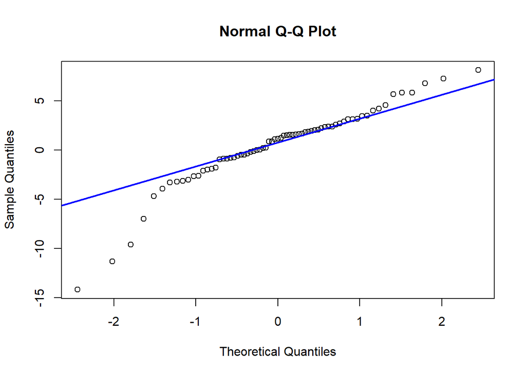

```r
sisaan.da <- model1$residuals
par(mfrow=c(1,1))
qqnorm(sisaan.da)
qqline(sisaan.da, col = "blue", lwd = 2)
```

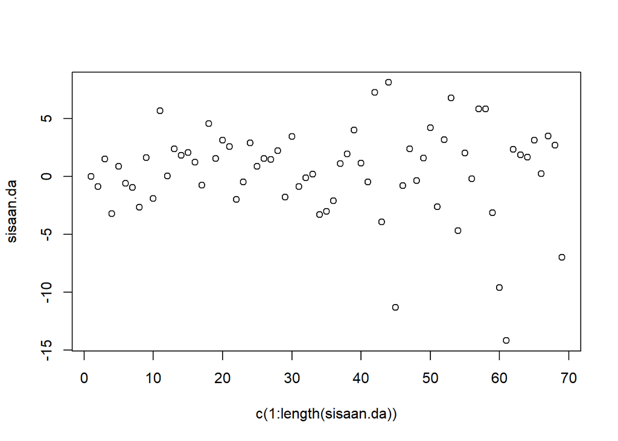

```r
plot(c(1:length(sisaan.da)),sisaan.da)
```

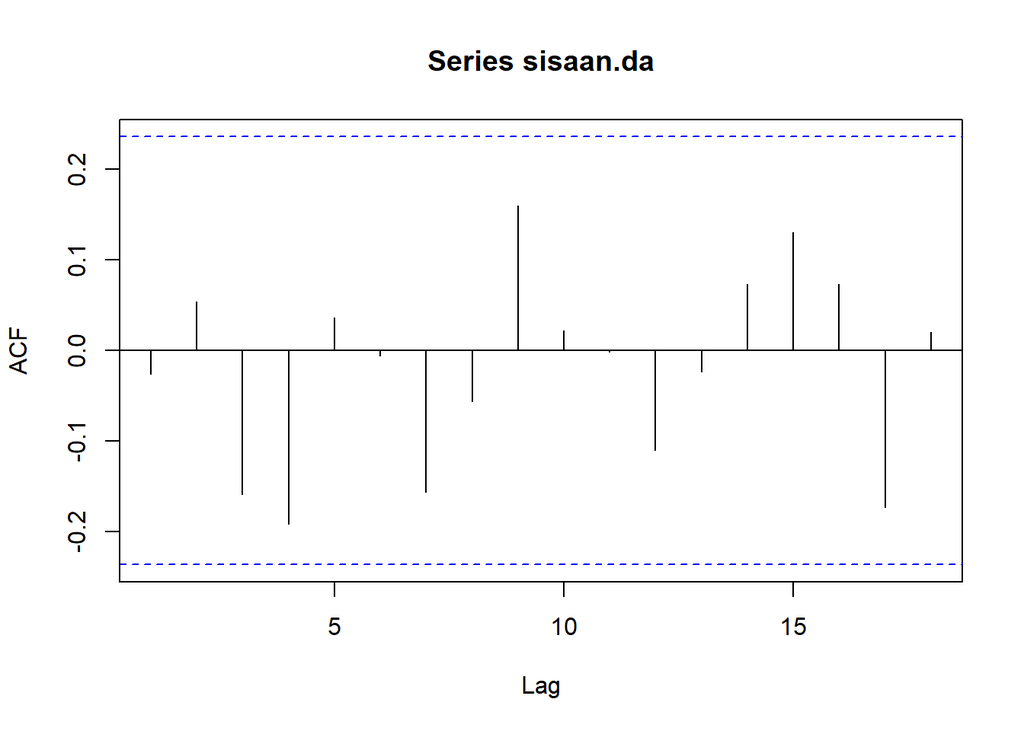

```r
acf(sisaan.da)
```

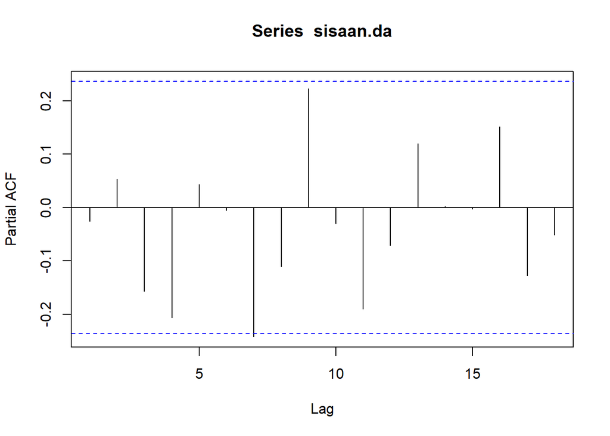

```r
pacf(sisaan.da)
```

### Uji Kenormalan

```r
ks.test(sisaan.da,"pnorm")  #tak tolak H0 > sisaan menyebar normal
```

```
##
##  Exact one-sample Kolmogorov-Smirnov test
##
## data:  sisaan.da
## D = 0.40632, p-value = 8.295e-11
## alternative hypothesis: two-sided
```

H0: Sisaan menyebar normal H1: Sisaan tidak menyebar normal

Berdasarkan uji Kolmogrov Smirnov, didapat p-value sebesar **8.295e-11* yang kurang dari taraf nyata 5% sehingga tolak H0. dan menandakan bahwa sisaan tidak menyebar normal.

### Uji Kebebasan (Identifikasi Korelasi)

```r
Box.test(sisaan.da, type = "Ljung")  #tak tolak H0 > sisaan saling bebas
```

```
##
##  Box-Ljung test
##
## data:  sisaan.da
## X-squared = 0.047815, df = 1, p-value = 0.8269
```

H0 : Sisaan saling bebas H1 : Sisaan tidak saling bebas Berdasarkan uji Ljung-Box , didapat p-value sebesar **0.8269** yang lebih besar dari taraf nyata 5% sehingga tak tolak H0. Hal ini menandakan bahwa sisaan saling bebas.

### Uji Kehomogenan ragam Sisaan

```r
Box.test((sisaan.da)^2, type = "Ljung")  #tak tolak H0 > sisaan homogen
```

```
##
##  Box-Ljung test
##
## data:  (sisaan.da)^2
## X-squared = 6.4221, df = 1, p-value = 0.01127
```

H0 : Ragam sisaan homogen H1 : Ragam sisaan tidak homogen

### Uji Nilai tengah sisaan sama dengan nol

```r
t.test(sisaan.da, mu = 0, conf.level = 0.95)  #tak tolak h0 > nilai tengah sisaan sama dengan 0
```

```
##
##  One Sample t-test
##
## data:  sisaan.da
## t = 0.91729, df = 68, p-value = 0.3622
## alternative hypothesis: true mean is not equal to 0
## 95 percent confidence interval:
##  -0.5049329  1.3641112
## sample estimates:
## mean of x
## 0.4295892
```

H0 : nilai tengah sisaan sama dengan 0 H1 : nilai tengah sisaan tidak sama dengan 0

Berdasarkan uji-t, didapat p-value sebesar **0.3622** yang lebih besar dari taraf nyata 5% sehingga tak tolak H0 menandakan bahwa nilai tengah sisaan sama dengan nol.

## Peramalan

```r
ramalan.da <- forecast(model1, h = 39)
ramalan.da
```

```
##     Point Forecast     Lo 80    Hi 80     Lo 95    Hi 95
##  71      1.2542381 -3.874217 6.382693 -6.589058 9.097534
##  72      0.9125483 -4.218013 6.043110 -6.933968 8.759065
##  73      0.9283807 -4.202342 6.059104 -6.918383 8.775145
##  74      0.9276471 -4.203069 6.058363 -6.919106 8.774401
##  75      0.9276811 -4.203035 6.058398 -6.919073 8.774435
##  76      0.9276795 -4.203037 6.058396 -6.919074 8.774433
##  77      0.9276796 -4.203037 6.058396 -6.919074 8.774433
##  78      0.9276796 -4.203037 6.058396 -6.919074 8.774433
##  79      0.9276796 -4.203037 6.058396 -6.919074 8.774433
##  80      0.9276796 -4.203037 6.058396 -6.919074 8.774433
##  81      0.9276796 -4.203037 6.058396 -6.919074 8.774433
##  82      0.9276796 -4.203037 6.058396 -6.919074 8.774433
##  83      0.9276796 -4.203037 6.058396 -6.919074 8.774433
##  84      0.9276796 -4.203037 6.058396 -6.919074 8.774433
```

[output cut: 25 more lines]

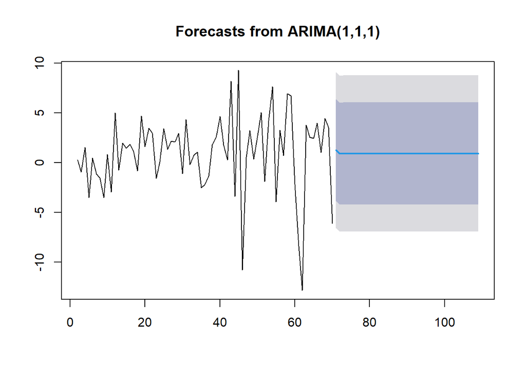

```r
data.ramalan.da <- ramalan.da$mean
plot(ramalan.da)
```

### Eksplorasi data hasil peramalan

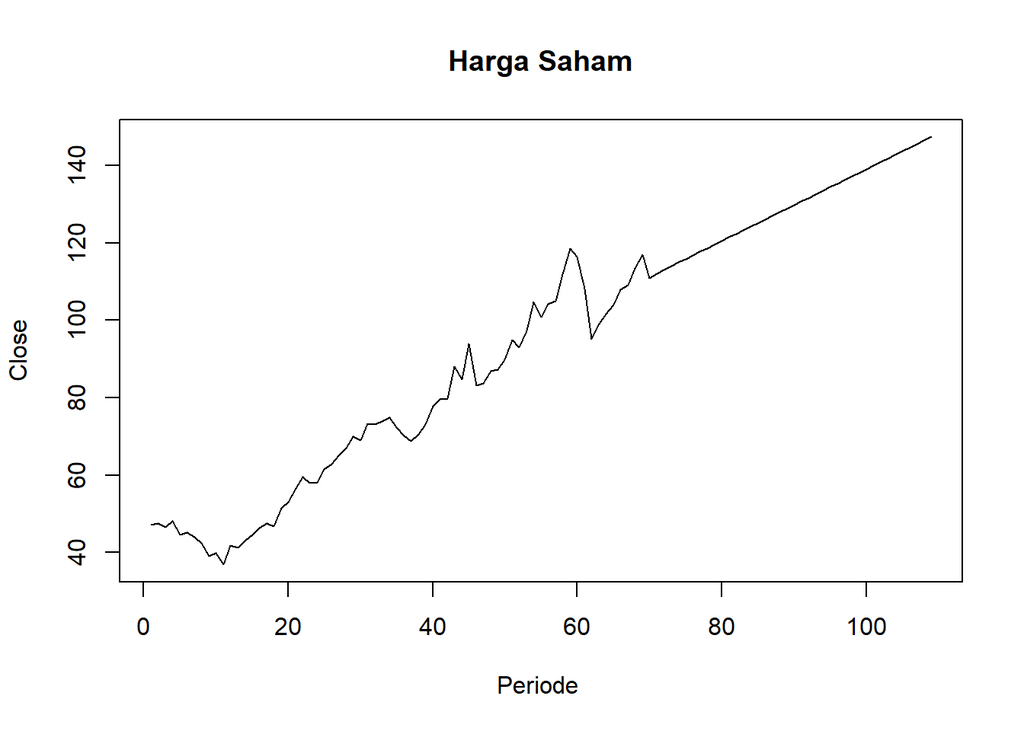

```r
pt_1 <- data_train[length(data_train)] #nilai akhir data latih
hasil.forc.Diff <- data.ramalan.da
hasil <- diffinv(hasil.forc.Diff, differences = 1) + pt_1
#has.1 sama hasilnta dengan: cumsum(c(pt_1,hasil.forc.Diff))
ts.plot(data_train,hasil,xlab="Periode ", ylab="Close",
        main = "Harga Saham")
```

### Perbandingan data Uji dengan data hasil peramalan

```r
perbandingan.da<-matrix(data=c(head(data_test, n=39), hasil[-1]),
                        nrow = 39, ncol = 2)
colnames(perbandingan.da)<-c("Aktual","Hasil Forecast")
perbandingan.da
```

```
##       Aktual Hasil Forecast
##  [1,] 114.56       112.1342
##  [2,] 105.31       113.0468
##  [3,] 110.53       113.9752
##  [4,] 123.10       114.9028
##  [5,] 132.21       115.8305
##  [6,] 128.24       116.7582
##  [7,] 123.78       117.6859
##  [8,] 120.75       118.6135
##  [9,] 123.49       119.5412
## [10,] 126.18       120.4689
## [11,] 117.91       121.3966
## [12,] 120.26       122.3243
## [13,] 109.05       123.2519
## [14,] 107.38       124.1796
```

[output cut: 25 more lines]

```r
selisih <- perbandingan.da[ ,1] -perbandingan.da[ ,2]
selisih <- as.matrix(abs(selisih))
colnames(selisih)<-c("Selisih antara Aktual dengan Forecast")
summary(selisih)
```

```
##  Selisih antara Aktual dengan Forecast
##  Min.   : 2.064
##  1st Qu.: 9.840
##  Median :31.323
##  Mean   :33.273
##  3rd Qu.:56.727
##  Max.   :71.794
```

Dari Hasil antara data Aktual dengan data peramalan didapatkan rata-rata selisih sebesar **33.273** dengan selisih terkecil sama dengan **2.064** dan selisih terbesar sebesar **71.794**

### Tingkat Akurasi

```r
accuracy(ts(hasil[-1]), head(data_test, n=39))
```

```
##                 ME     RMSE      MAE       MPE     MAPE      ACF1 Theil's U
## Test set -30.38194 40.56869 33.27296 -36.04645 38.33031 0.9375488  9.063031
```